# Your Digest for Sunday, Jan 14, 2024 11:59 PM

# Trichomonas vaginalis

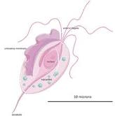

# Gardnerella vaginalis

[figure not shown]

> [!INFO] PTH and D3 affect calcium more than phosphate
> - In clinical scenarios, both hormone have a more significant effect on calcium metabolism than phosphate metabolism.
> - A patient presenting with abnormal calcium will often be found to have a hormone abnormality but
> - a patient presenenting with abnormal phosphate will be less likely to have a PTH/D3 abnormality.

```
+ Most common ones are : **beta blockers**, **lithium**, **antimalarial** drugs, **NSAIDS** and **tetracyclines**. (also exacerbation)
+ **TNF inhibitors** can paradoxically cause exacerbations of psoriasis. (eg infliximab)
```

LP

LP on flexor aspect of wrist

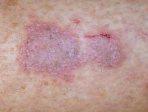

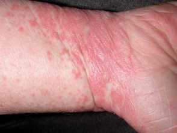

> [!INFO] Lichen planus: described by **4 P's**  
> Slowly (and spontaneously) resolving T cell mediated autoimmune disease
- Cause is unknown.
- Typical lesions have a **Violaceous** / lilac colour.
- **intensely** itchy!
- Flat topped lesions.
- Wickham's striae are seen in **older** people.
- **Wickhams striae**: white lace - like patterns on the surface of lesions. - seen in *most* but *not all*
  - Cutaneous wickhams is seen in all patients.
  - *Oral wickhams striae is seen only in 50% of patients*.

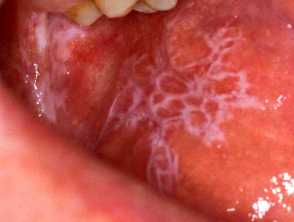

- Affects skin,**mucous membranes** (*especially the oral mucosa*), scalp, nails, and genitalia - see UpToDate images  
  **Pathogenesis**: - possible autoimmune based involving *CD 8 T cells*  
  **Histology**:
- *Hyperkeratosis **without parakeratosis***
- Small clefts at the dermal-epidermal junction (*Max-Joseph spaces*)
- Band-like, *lymphocytic infiltrate at the dermal-epidermal junction*
- Eosinophilic, colloid bodies (*apoptotic keratinocytes*) in the papillary dermis
- **Pigment incontinence** (most prominent in dark-skinned individuals)  
  **Management**:
- Cutaneous lichen planus *usually resolves within **2 years***.
- Treatment is focused on decreasing time to resolution and managing pruritus.
- Local steroid, systemic steroids are the mainstay although not backed by good evidence.
- Retinoids may be used.
- + other drugs  
  **Differential diagnosis**:
- lichenoid reaction to certain drugs

> [!INFO] Thiazides  
> Thiazides are one drug class than can cause lichenoid reaction.

# Skin cancers

Squamous cell CA

Chronic non healing ulcers

Metastasis is uncommon. (upto 5%)

RF: Sunlight, smoking, chronic ulcers,

Occurs on areas of ⬆ sun exposure

Rx: Excission with 4mm margins.

Mohs micrographic surgery in high risk /  
cosmetically sensitive areas.

Poor prognosis  
if > 20mm wide or  
> 4mm deep

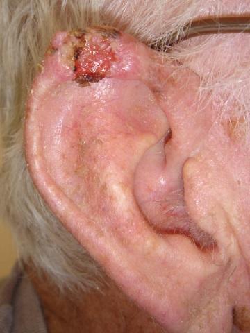

**SGLT2 inhibitors are not appropriate** for use in patients with *type 1 diabetes and kidney disease.*

## Management of type 1 [[Diabetes]]

- **Mainstay** of management is insulin.
- NICE recomments metformin as add on therapy (esp. if BMI > 25)
  - It increases sensitivity to insulin enabling lower doses.
  - also has cardiovascular benefits.
- SGLT-2 inhibitors are not used.

Mechanism: dihydroxycholecalciferol binds to it's receptor and acts as a **transcription regulator** which increases **calbindin D** proteins.  
**Calbindin** increases intestinal calcium absorption.

Clostridium tetani is a gram positive rod. It will not grow in healthy tissues.

- Tetanospasmin is an exotoxin produced by the bacteria.
- It is a potent neurotoxin.  
  It **enters *peripheral* motor nerves** and **travels to the CNS** where it *inhibits GABA (which is itself inhibitory)*. There is subsequent *loss of inhibition* of the anterior horn cells -> painful muscle spasm.
- Loss of inhibition of autonomic nerves: *Severe autonomic instability*; **sweating, tachycardia and hypertension**.
- The effects on the neurons are **long lasting** because recovery **requires the growth of new axonal nerve terminals**  
  Tetanus has a very variable incubation period; upto 21 days! PEP should be given if patient presents up to 21 days after exposure.
- C tetani is sensitive to **penicillin and metronidazole**.
- Mainstay is **Benzodiazepine** and **MgSO4**.
- Tetanus **does not induce immunity**. So all patient should get active and passive immunization following tetanus infection.

[output not shown]

- The HIV virus replicates **within CD4 cells** in the lymph nodes -> **lymphadenopathy**.

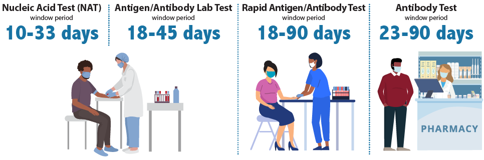

From MSD msdmanuals

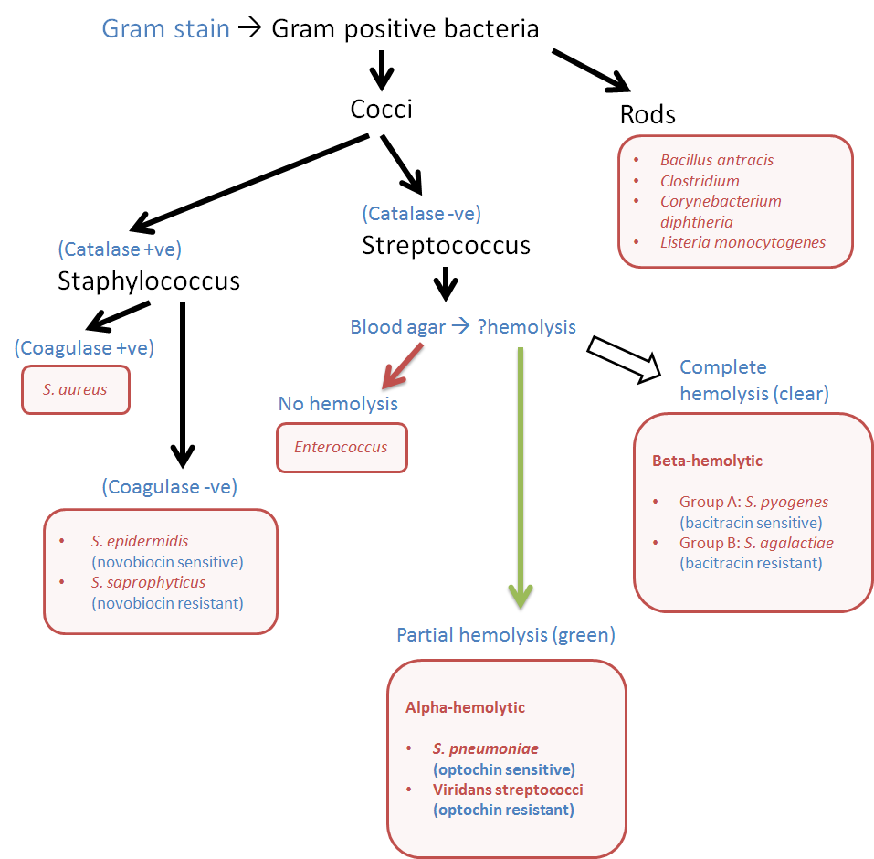

-from passMedicine

- **Effective renal plasma flow** can be calculated using the Fick principle with *para-amino hippuric acid*.
- If effective renal plasma flow is around 630ml, **renal blood flow is 1273 mL/min**.

| Lesion | Association | Mnemonic |
| --- | --- | --- |
| Erythema gyratum repens | Lung cancer | Forests (wood grain appearance of rash) are the lungs of the world |
| Acanthosis nigricans | Gastric CA | AN is connected to things relating to fat / stomach / tummy |
| Acquired ichthyosis | Lymphoma | Lymfishma |
| Acquired hypertrichosis lanuginosao | GI and lung cancer | Fat hair man who smokes and drinks |
| Dermatomyositis | Ovarian Ca, Lung CA | Common in women -> ovaries. Also, lungs Associated with "paired organs" |
| Migratory thrombophlebitis | Pancreatic CA | Let's assume scorpion stings also case thrombosis |
| Necrolytic migratory erythema | Glucagonoma | Always carry glucose while migrating |
| Pyoderma gangrenosum | myeloproliferative disorders | pyo/myo |
| Sweet syndrome | Haematologic malignancies | Sweets raise *blood* sugar |
| Tylosis | Oesophageal cancer | Tie a tie around the oesophagus |

> [!INFO] How to remember this nonsense  
> Skin disorders of malignancy:
> - **Erythema gyratum repens** - lung cancer - wood grain appearance, *forests are the lungs of the world*
> - **Acanthosis nigricans** - gastric ca - always goes along with *fat/tummy related things*
> - **Acquired ichthyosis** - lymphoma - *lymfishma*
> - **Acquired hypertrichosis lanuginosa** - GI and lung cancer - hairy man who smokes and drinks
> - **Dermatomyositis** - ovarian and lung ca - always think of this one as paired with myositis, these are paired organs
> - **Migratory thrombophlebitis** - pancreatic cancer - are scorpion stings also prothrombotic? Let’s imagine yes
> - **Necrolytic migratory erythema** - glucagonoma - always carry some glucose whilst migrating
> - **Pyoderma gangrenosum** - myeloproliferative disorders - pyo/myo
> - **Sweet syndrome** - haematological malignancies - sweets increase blood sugar
> - **Tylosis** - oesophageal cancer - tie a tie around your oesophagus

# Bacterial toxins

- Endotoxins - released only when the cells are lysed. They are usually *lipopolysaccharides*.
  - Generally part of gram negative bacteria.
- Exotoxins - secreted by the bacterial cells.
  - **Exotoxins** are generally released by **gram positive bacteria.**
  - Notable exceptions (i.e gram -ves) are **vibrio cholerae** and some species of **E. coli**.